# Cell type classification with SignacX: 1k PBMCs from 10X Genomics

Compiled 2021-03-01

This vignette shows how to use Signac with Seurat. There are three parts: Seurat, Signac and then visualization. We use an example PBMCs scRNA-seq data set from 10X Genomics.

## Seurat

Start with the standard pre-processing steps for a Seurat object.

```r
library(Seurat)
```

Download data from 10X Genomics.

```r
dir.create("fls")
download.file("https://cf.10xgenomics.com/samples/cell-exp/3.0.0/pbmc_1k_v3/pbmc_1k_v3_filtered_feature_bc_matrix.h5",
    destfile = "fls/pbmc_1k_v3_filtered_feature_bc_matrix.h5")
```

Create a Seurat object, and then perform SCTransform normalization. Note:

- You can use the legacy functions here (i.e., NormalizeData, ScaleData, etc.), use SCTransform or any other normalization method (including no normalization). We did not notice a significant difference in cell type annotations with different normalization methods.
- We think that it is best practice to use SCTransform, but it is not a necessary step. Signac will work fine without it.

```r
# load data
E = Read10X_h5(filename = "fls/pbmc_1k_v3_filtered_feature_bc_matrix.h5")
pbmc <- CreateSeuratObject(counts = E, project = "pbmc")

# run sctransform
pbmc <- SCTransform(pbmc, verbose = FALSE)
```

Perform dimensionality reduction by PCA and UMAP embedding. Note:

- Signac actually needs these functions since it uses the nearest neighbor graph generated by Seurat.

```r
# These are now standard steps in the Seurat workflow for visualization and clustering
pbmc <- RunPCA(pbmc, verbose = FALSE)
pbmc <- RunUMAP(pbmc, dims = 1:30, verbose = FALSE)
pbmc <- FindNeighbors(pbmc, dims = 1:30, verbose = FALSE)
```

## SignacX

First, make sure you have the Signac package installed.

```r
install.packages("SignacX")
```

Load the library

```r
# load library
library(SignacX)
```

Generate SignacX labels for the Seurat object. Note:

- Optionally, you can do parallel computing by setting num.cores > 1 in the Signac function.
- Run time is ~10 minutes for ~10,000 cells.

```r
# Run Signac
labels <- Signac(pbmc, num.cores = 4)
celltypes = GenerateLabels(labels, E = pbmc)
```

Sometimes, training the neural networks takes a lot of time. To make Signac faster, we implemented SignacFast which uses an ensemble of pre-trained neural network models. Note:

- SignacFast uses an ensemble of 1,800 pre-calculated neural networks rather than performing bespoke model training.

```r
# Run Signac
labels_fast <- SignacFast(pbmc)
celltypes_fast = GenerateLabels(labels_fast, E = pbmc)
```

SignacFast took only ~30 seconds. Relative to Signac, the main difference is that SignacFast tends to leave a few more cells “Unclassified.”

**How does SignacFast compare to Signac?**

|  | B | MPh | TNK | Unclassified |
| --- | --- | --- | --- | --- |
| B | 186 | 0 | 0 | 0 |
| MPh | 0 | 362 | 0 | 54 |
| TNK | 0 | 0 | 573 | 3 |
| Unclassified | 0 | 0 | 0 | 44 |

## Visualizations

Now we can visualize the cell type classifications at many different levels: Immune and nonimmune

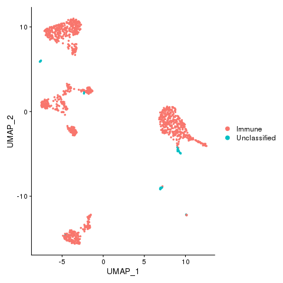

Immune, Nonimmune (if any) and unclassified cells

```r
pbmc <- AddMetaData(pbmc, metadata = celltypes$Immune, col.name = "immmune")
pbmc <- SetIdent(pbmc, value = "immmune")
png(filename = "fls/plot1.png")
DimPlot(pbmc)
dev.off()
```

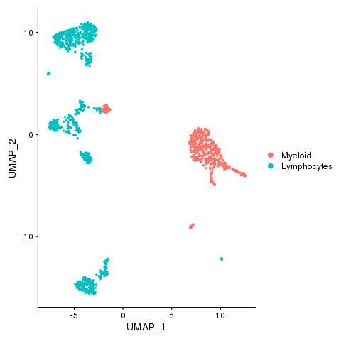

Myeloid and lymphocytes

```r
pbmc <- AddMetaData(pbmc, metadata = celltypes$L2, col.name = "L2")
pbmc <- SetIdent(pbmc, value = "L2")
png(filename = "fls/plot2.png")
DimPlot(pbmc)
dev.off()
```

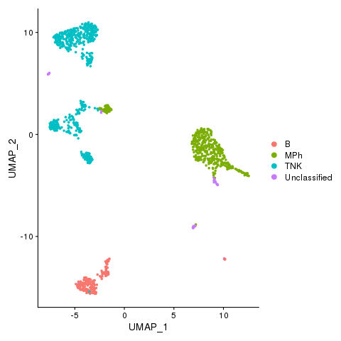

Cell types

```r
lbls = factor(celltypes$CellTypes)
levels(lbls) <- sort(unique(lbls))
pbmc <- AddMetaData(pbmc, metadata = lbls, col.name = "celltypes")
pbmc <- SetIdent(pbmc, value = "celltypes")
png(filename = "./fls/plot3.png")
DimPlot(pbmc)
dev.off()
```

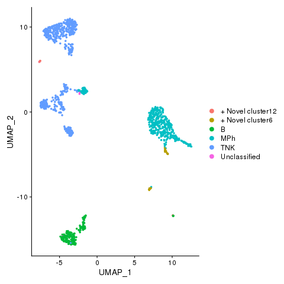

Cell types with novel populations

```r
pbmc <- AddMetaData(pbmc, metadata = celltypes$CellTypes_novel, col.name = "celltypes_novel")
pbmc <- SetIdent(pbmc, value = "celltypes_novel")
png(filename = "./fls/plot4.png")
DimPlot(pbmc)
dev.off()
```

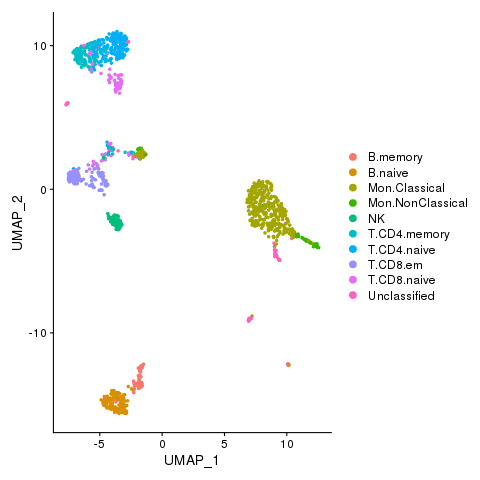

Cell states

```r
pbmc <- AddMetaData(pbmc, metadata = celltypes$CellStates, col.name = "cellstates")
pbmc <- SetIdent(pbmc, value = "cellstates")
png(filename = "./fls/plot5.png")
DimPlot(pbmc)
dev.off()
```

Identify differentially expressed genes between cell types. Here, we see that Signac identified two novel cell populations that are positive for platelet and plasma cell markers, respectively.

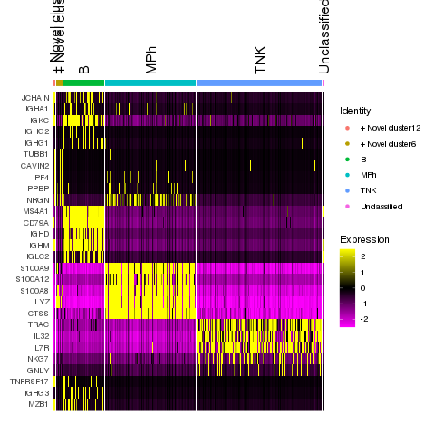

Immune marker genes

```r
pbmc <- SetIdent(pbmc, value = "celltypes_novel")

# Find protein markers for all clusters, and draw a heatmap
markers <- FindAllMarkers(pbmc, only.pos = TRUE, verbose = F, logfc.threshold = 1)
library(dplyr)
top5 <- markers %>% group_by(cluster) %>% top_n(n = 5, wt = avg_logFC)
png(filename = "./fls/plot6.png")
DoHeatmap(pbmc, features = unique(top5$gene), angle = 90)
dev.off()
```

Save results

```r
saveRDS(pbmc, file = "fls/pbmcs_signac.rds")
saveRDS(celltypes, file = "fls/celltypes.rds")
saveRDS(celltypes_fast, file = "fls/celltypes_fast.rds")
```